# Household Expenditure and Podcast Performance: Regression Analysis in R

# Part 1: Household Expenditure in England

This dataset contains weekly expenditure information for households in England, with each row representing one household. The primary outcome of interest is weekly food expenditure (£). Explanatory variables include household composition, respondent characteristics, and weekly spending on housing, alcohol, and non-mortgage debt repayments.

The analysis examines how these factors relate to food expenditure, with particular focus on alcohol spending and whether its association with food expenditure differs across households with different levels of debt.

The table below provides a brief description of each variable in the data set

# Data Dictionary

| Variable | Description |
| --- | --- |
| Kids | Total Number of children in the household |
| Household Size | Total number of individuals residing in the household |
| Sex | Gender of the survey respondent |
| Vehicles | Total Number of vehicles in the household |
| Food | Average weekly household expenditure on food,measured in pounds (£) |
| Housing | Average weekly household housing costs,including rent or mortgage payments, measured in pounds (£) |
| Alcohol | Average weekly household expenditure on alcoholic beverages, measured in pounds (£) |
| Debt | Average weekly household repayments on non-mortgage debt, measured in pounds (£) |
| Income_category | Categorical indicator of household income level: Low, Medium, or High |

# Data overview

```r
# Reading csv file
household <- read_csv("HouseholdExpenditure.csv")

# Summary statistics
summary(household)
```

```
      Kids        HouseholdSize        Sex               Vehicles          Food
 Min.   :0.0000   Min.   : 1.000   Length:4097        Min.   :0.000   Min.   : 12.25
 1st Qu.:0.0000   1st Qu.: 1.000   Class :character   1st Qu.:0.000   1st Qu.: 48.59
 Median :0.0000   Median : 2.000   Mode  :character   Median :1.000   Median : 57.27
 Mean   :0.5849   Mean   : 2.378                      Mean   :1.077   Mean   : 57.44
 3rd Qu.:1.0000   3rd Qu.: 3.000                      3rd Qu.:2.000   3rd Qu.: 66.21
 Max.   :8.0000   Max.   :11.000                      Max.   :7.000   Max.   :103.54
 NA's   :6        NA's   :6
    Housing         Alcohol            Debt        income_category
 Min.   :155.9   Min.   : 7.429   Min.   :  0.00   Length:4097
 1st Qu.:281.8   1st Qu.:14.920   1st Qu.: 49.46   Class :character
 Median :314.1   Median :17.012   Median : 59.85   Mode  :character
 Mean   :319.2   Mean   :17.014   Mean   : 59.97
 3rd Qu.:351.3   3rd Qu.:19.099   3rd Qu.: 70.78
 Max.   :639.2   Max.   :27.658   Max.   :148.41
                                  NA's   :8
```

```r
glimpse(household)
```

```
Rows: 4,097
Columns: 9
$ Kids            <dbl> 0, 4, 2, 0, 0, 0, 3, 3, 2, 3, 2, 0, 0, 0, 0, 0, 0, 0, 0, 0, 0, 0, 0, 0, 0,…
$ HouseholdSize   <dbl> 3, 5, 3, 2, 1, 1, 6, 5, 4, 4, 4, 1, 2, 2, 2, 2, 1, 1, 1, 1, 2, 2, 3, 1, 3,…
$ Sex             <chr> "male", "female", "female", "male", "female", "male", "male", "male", "mal…
$ Vehicles        <dbl> 0, 1, 2, 0, 1, 0, 1, 1, 2, 3, 1, 1, 2, 2, 1, 2, 0, 1, 1, 2, 2, 2, 1, 0, 1,…
$ Food            <dbl> 71.916, 48.162, 61.355, 55.090, 53.758, 34.579, 70.244, 70.791, 42.568, 84…
$ Housing         <dbl> 349.40, 288.99, 299.56, 300.69, 258.07, 261.11, 460.16, 305.78, 269.13, 28…
$ Alcohol         <dbl> 16.659, 17.344, 18.861, 16.811, 14.131, 13.446, 15.230, 20.721, 18.642, 19…
$ Debt            <dbl> 59.050, 76.842, 47.805, 85.109, 68.687, 32.706, 106.113, 55.882, 59.616, 6…
$ income_category <chr> "High", "Medium", "Low", "High", "Medium", "Low", "Medium", "Medium", "Med…
```

```r
# Checking missing values per variable
colSums(is.na(household))
```

```
           Kids   HouseholdSize             Sex        Vehicles            Food         Housing
              6               6               6               0               0               0
        Alcohol            Debt income_category
              0               8               6
```

Overall, the data appear suitable for modelling, with no clear evidence of abnormal values or implausible outliers after handling a small amount of missing data

# Handling Inconsistency in data

To ensure consistency and comparability across analyses, only households with complete information on all relevant variables were retained. Moreover, Categorical variables were converted to factors prior to modelling

```r
#filtering out missing data
Filtered_data <- household %>%
  filter(
    !is.na(Kids),
    !is.na(HouseholdSize),
    !is.na(Sex),
    !is.na(Vehicles),
    !is.na(Food),
    !is.na(Housing),
    !is.na(Alcohol),
    !is.na(Debt),
    !is.na(income_category))
```

```r
# Converting categorical variables to factors
Filtered_data <- Filtered_data %>% mutate(income_category = factor(income_category,levels=c("Low","Medium","High")),Sex = factor(Sex))
```

# Visualizing distributions of variables of interest

## Food Distribution

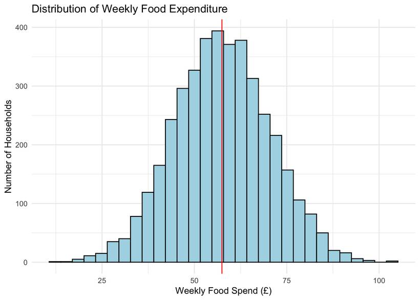

```r
ggplot(Filtered_data, aes(Food)) +
geom_histogram(bins = 30, fill = "lightblue", colour = "black") +
geom_vline(aes(xintercept = mean(Food)), colour = "red") +
theme_minimal() +
labs(title = "Distribution of Weekly Food Expenditure",
x = "Weekly Food Spend (£)", y = "Number of Households")
```

**Interpretation**

Weekly food expenditure is broadly centred around typical values with a mild right tail. The pattern appears plausible for household spending data, with no obvious anomalies that would prevent linear modelling

## Alcohal Distribution

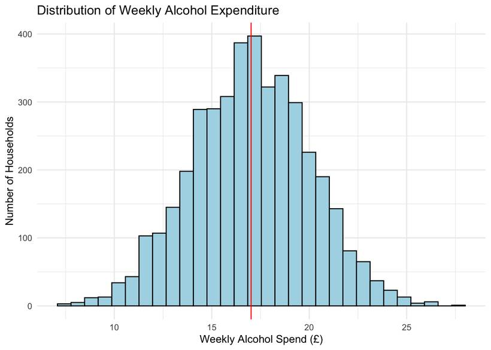

```r
ggplot(Filtered_data, aes(Alcohol)) +
geom_histogram(bins = 30, fill = "lightblue", colour = "black") +
geom_vline(aes(xintercept = mean(Alcohol)), colour = "red") +
theme_minimal() +
labs(title = "Distribution of Weekly Alcohol Expenditure",
x = "Weekly Alcohol Spend (£)", y = "Number of Households")
```

**Interpretation**

Alcohol expenditure is concentrated around modest weekly amounts with mild skew. The distribution looks plausible and suitable for use as a continuous predictor

## Debt Payments Distribution

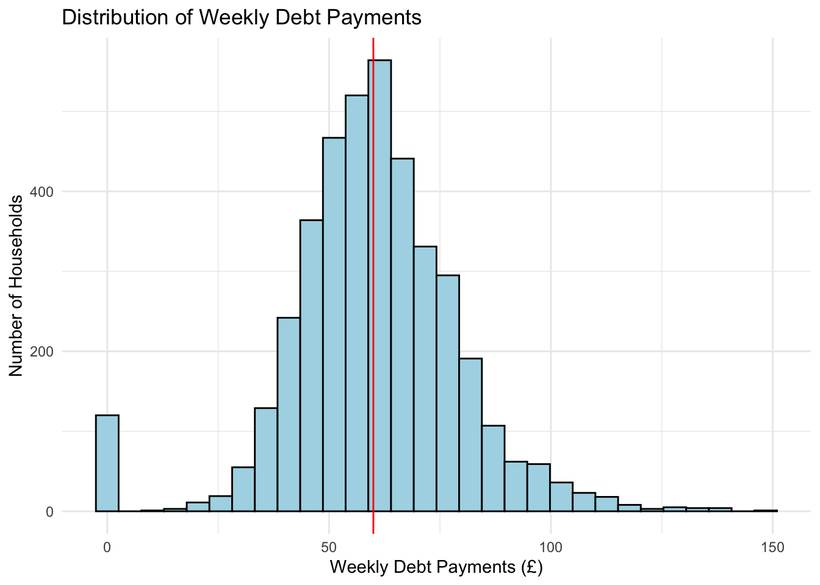

```r
ggplot(Filtered_data, aes(Debt)) +
geom_histogram(bins = 30, fill = "lightblue", colour = "black") +
geom_vline(aes(xintercept = mean(Debt)), colour = "red") +
theme_minimal() +
labs(title = "Distribution of Weekly Debt Payments",
x = "Weekly Debt Payments (£)", y = "Number of Households")
```

**Interpretation**

Debt repayments vary widely, with many households clustered at lower repayment levels and fewer households at higher values. This pattern is consistent with meaningful differences in financial obligations rather than data error

# Visualizing Relationships of variables of interest

## Food vs Alcohol

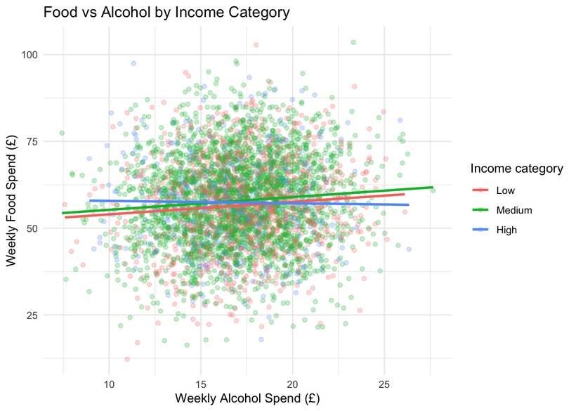

```r
ggplot(Filtered_data, aes(x = Alcohol, y = Food, colour = income_category)) +
geom_point(alpha = 0.25) +
geom_smooth(method = "lm", se = FALSE) +
theme_minimal() +
labs(title = "Food vs Alcohol by Income Category",
x = "Weekly Alcohol Spend (£)", y = "Weekly Food Spend (£)",
colour = "Income category")
```

## Food vs Debt

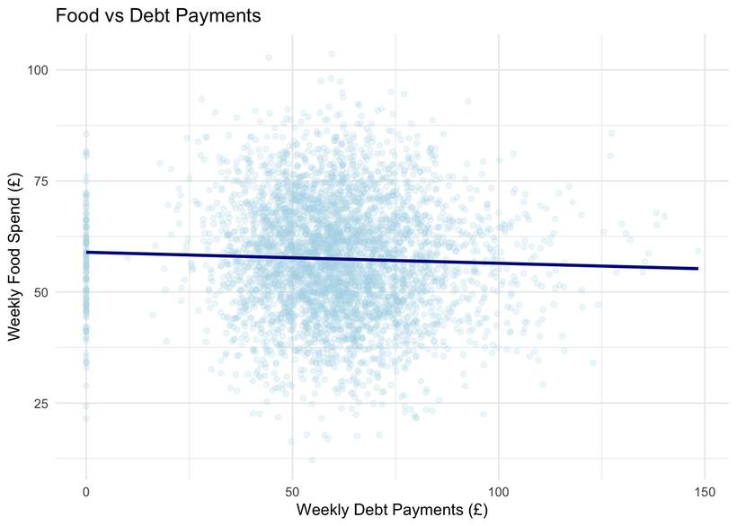

```r
ggplot(Filtered_data, aes(x = Debt, y = Food)) +
geom_point(alpha = 0.2, colour = "lightblue") +
geom_smooth(method = "lm", se = FALSE, colour = "darkblue") +
theme_minimal() +
labs(title = "Food vs Debt Payments",
x = "Weekly Debt Payments (£)", y = "Weekly Food Spend (£)")
```

**Interpretation**

Visual inspection suggests a weak negative association between debt repayments and food expenditure. While the fitted line indicates a slightly decreasing trend, the scatter remains substantial, suggesting debt alone explains limited variation in food spending

## Food vs Housing.

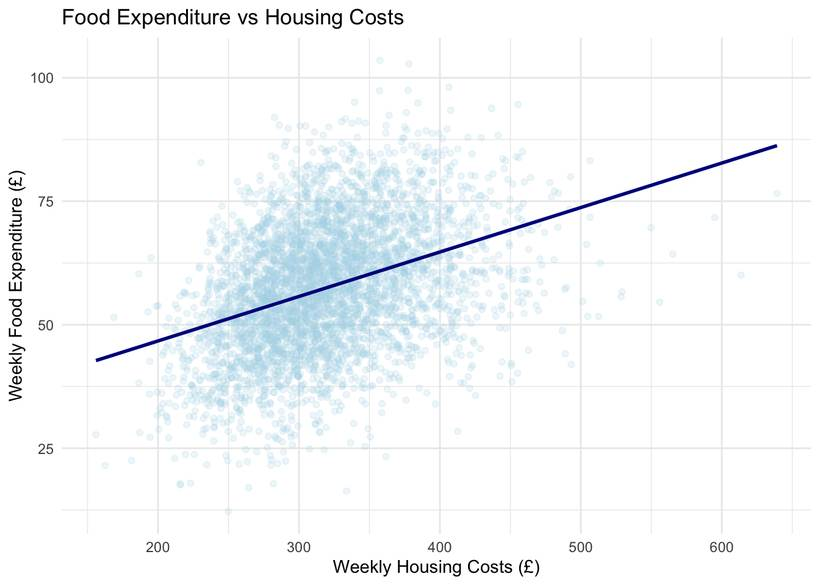

```r
ggplot(Filtered_data, aes(x = Housing, y = Food)) + geom_point(alpha = 0.2, colour = "lightblue") +
geom_smooth(method = "lm", se = FALSE, colour = "darkblue") +
  theme_minimal() +
  labs(
    title = "Food Expenditure vs Housing Costs",
    x = "Weekly Housing Costs (£)",
    y = "Weekly Food Expenditure (£)")
```

**Interpretation**

Visual inspection suggests a clear positive association between housing costs and food expenditure. Households with higher housing costs also tend to spend more on food, and the fitted line indicates a broadly increasing trend

# Food vs Alcohol across debt bands

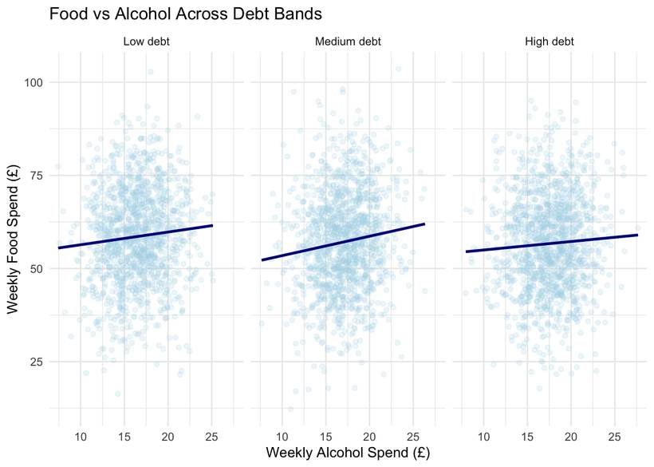

```r
Filtered_data %>%
mutate(DebtBand = cut(
Debt,
breaks = quantile(Debt, probs = c(0, .33, .66, 1), na.rm = TRUE),
include.lowest = TRUE,
labels = c("Low debt", "Medium debt", "High debt")
)) %>%
ggplot(aes(x = Alcohol, y = Food)) +
geom_point(alpha = 0.2, colour = "lightblue") +
geom_smooth(method = "lm", se = FALSE, colour = "darkblue") +
facet_wrap(~ DebtBand) +
theme_minimal() +
labs(title = "Food vs Alcohol Across Debt Bands",
x = "Weekly Alcohol Spend (£)", y = "Weekly Food Spend (£)")
```

**Interpretation**

The fitted lines appear broadly similar across low, medium, and high-debt groups. There is no clear visual evidence that the alcohol–food relationship differs by debt level, motivating formal interaction testing

**Together, all these distributions appear realistic and appropriate for linear modelling**

# Model 1 (Main Effects)

A multiple linear regression model was fitted to examine whether household characteristics and expenditure variables explain variation in weekly food expenditure

```r
Food_Lm <- lm(
Food ~ HouseholdSize + Kids + Vehicles + Housing + income_category + Sex + Alcohol + Debt, data = Filtered_data)

summary(Food_Lm)
```

```
Call:
lm(formula = Food ~ HouseholdSize + Kids + Vehicles + Housing +
    income_category + Sex + Alcohol + Debt, data = Filtered_data)

Residuals:
    Min      1Q  Median      3Q     Max
-42.300  -8.124  -0.090   8.081  39.699

Coefficients:
                       Estimate Std. Error t value Pr(>|t|)
(Intercept)           23.472590   1.688695  13.900  < 2e-16 ***
HouseholdSize          0.175645   0.291747   0.602   0.5472
Kids                  -0.412563   0.354191  -1.165   0.2442
Vehicles               0.360337   0.216622   1.663   0.0963 .
Housing                0.091439   0.003485  26.241  < 2e-16 ***
income_categoryMedium  0.928248   0.477733   1.943   0.0521 .
income_categoryHigh    0.392923   0.749619   0.524   0.6002
Sexmale               -0.083423   0.405226  -0.206   0.8369
Alcohol                0.388444   0.062415   6.224 5.35e-10 ***
Debt                  -0.049175   0.009718  -5.060 4.38e-07 ***
---
Signif. codes:  0 '***' 0.001 '**' 0.01 '*' 0.05 '.' 0.1 ' ' 1

Residual standard error: 11.91 on 4073 degrees of freedom
Multiple R-squared:  0.1536,    Adjusted R-squared:  0.1517
F-statistic:  82.1 on 9 and 4073 DF,  p-value: < 2.2e-16
```

```r
confint(Food_Lm)
```

```
                             2.5 %      97.5 %
(Intercept)           20.161823787 26.78335593
HouseholdSize         -0.396338881  0.74762984
Kids                  -1.106971175  0.28184507
Vehicles              -0.064361166  0.78503482
Housing                0.084606809  0.09827037
income_categoryMedium -0.008370389  1.86486603
income_categoryHigh   -1.076740484  1.86258585
Sexmale               -0.877887408  0.71104218
Alcohol                0.266075449  0.51081238
Debt                  -0.068228709 -0.03012171
```

**Interpretation**

**NHST: Overall Model Test**

H₀: None of the predictors explain Food spending

H₁: At least one predictor affects Food spending.

The overall model was statistically significant, F(9, 4073) = 82.10, p < .001, providing strong evidence against the null hypothesis that none of the predictors are associated with food expenditure.

**Model Fit**

The model explained 15.4% of the variation in weekly food expenditure (R² = 0.154, adjusted R² = 0.152),indicating a moderate fit for cross sectional household expenditure data.

**Key Estimates (Estimation Approach)**

Housing expenditure was the strongest predictor. Holding other variables constant, each additional £1 per week spent on housing was associated with an estimated £0.09 increase in food expenditure (β = 0.091, 95% CI [0.085, 0.098], p < .001).

Alcohol expenditure was positively associated with food spending.Each additional £1 spent on alcohol was associated with an estimated £0.39 increase in food expenditure (β = 0.388, 95% CI [0.266, 0.511], p < .001).

Debt repayments were negatively associated with food expenditure. Each additional £1 per week in debt repayments was associated with an estimated £0.05 decrease in food expenditure (β = −0.049, 95% CI [−0.068, −0.030], p < .001).

**Non-Significant Predictors**

Household size, number of children, number of vehicles, income category, and respondent sex were not statistically significant while housing, alcohol, and debt expenditures were included in the model.

**Conclusion**

Overall, food expenditure is more strongly related to other financial commitments particularly housing costs, alcohol spending and debt repayments rather than the household demographic characteristics. Although the model is statistically significant, a large proportion of variation in food expenditure remains unexplained

# Model 2 (Interaction: Does Debt change Alcohol’s effect?)

A multiple linear regression model was fitted to examine whether household characteristics and expenditure variables explain variation in weekly food expenditure

```r
Food_Lm_Int <- lm(
Food ~ HouseholdSize + Kids + Vehicles + Housing +
income_category + Sex + Alcohol * Debt,
data = Filtered_data
)

summary(Food_Lm_Int)
```

```
Call:
lm(formula = Food ~ HouseholdSize + Kids + Vehicles + Housing +
    income_category + Sex + Alcohol * Debt, data = Filtered_data)

Residuals:
    Min      1Q  Median      3Q     Max
-42.266  -8.132  -0.073   8.076  39.685

Coefficients:
                       Estimate Std. Error t value Pr(>|t|)
(Intercept)           21.915513   3.553285   6.168  7.6e-10 ***
HouseholdSize          0.175203   0.291776   0.600   0.5482
Kids                  -0.413691   0.354231  -1.168   0.2429
Vehicles               0.358828   0.216663   1.656   0.0978 .
Housing                0.091406   0.003486  26.224  < 2e-16 ***
income_categoryMedium  0.929349   0.477782   1.945   0.0518 .
income_categoryHigh    0.398080   0.749760   0.531   0.5955
Sexmale               -0.086225   0.405303  -0.213   0.8315
Alcohol                0.481121   0.196267   2.451   0.0143 *
Debt                  -0.022715   0.054008  -0.421   0.6741
Alcohol:Debt          -0.001549   0.003110  -0.498   0.6185
---
Signif. codes:  0 '***' 0.001 '**' 0.01 '*' 0.05 '.' 0.1 ' ' 1

Residual standard error: 11.92 on 4072 degrees of freedom
Multiple R-squared:  0.1536,    Adjusted R-squared:  0.1515
F-statistic:  73.9 on 10 and 4072 DF,  p-value: < 2.2e-16
```

```r
confint(Food_Lm_Int)
```

```
                             2.5 %       97.5 %
(Intercept)           14.949131847 28.881893918
HouseholdSize         -0.396836589  0.747243120
Kids                  -1.108177360  0.280795586
Vehicles              -0.065950708  0.783606795
Housing                0.084572459  0.098239679
income_categoryMedium -0.007365523  1.866064042
income_categoryHigh   -1.071858860  1.868019463
Sexmale               -0.880839790  0.708389751
Alcohol                0.096330125  0.865912496
Debt                  -0.128599782  0.083169216
Alcohol:Debt          -0.007646147  0.004548258
```

**Interpretation**

**NHST: Overall Model Test**

H₀: None of the predictors are associated with food expenditure

H₁: At least one predictor is associated with food expenditure

The interaction model remained statistically significant, F(10, 4072) = 73.90, p < .001,with virtually identical explanatory power to the main-effects model (R² = 0.154, adjusted R² = 0.152)

**Interaction Term (Estimation + NHST)**

The Alcohol × Debt interaction was not statistically significant(β = −0.00155, 95% CI [−0.00765, 0.00455], p = .619).This indicates no evidence that debt moderates the association between alcohol expenditure and food expenditure

# Anova Test

An ANOVA was used to assess whether adding an Alcohol × Debt interaction improves model fit compared with the main-effects model

```r
anova(Food_Lm, Food_Lm_Int)
```

```
Analysis of Variance Table

Model 1: Food ~ HouseholdSize + Kids + Vehicles + Housing + income_category +
    Sex + Alcohol + Debt
Model 2: Food ~ HouseholdSize + Kids + Vehicles + Housing + income_category +
    Sex + Alcohol * Debt
  Res.Df    RSS Df Sum of Sq      F Pr(>F)
1   4073 578186
2   4072 578150  1    35.221 0.2481 0.6185
```

**Interpretation**

An ANOVA comparison between the main-effects model and the interaction model confirmed that including the interaction did not improve model fit, F(1, 4072) = 0.25, p = .619.

**Conclusion**

There is no evidence that the relationship between alcohol expenditure and food expenditure varies across households with different levels of debt. The effect of alcohol spending on food expenditure appears broadly similar regardless of debt repayment levels.

# Emmeans

Estimated marginal means were calculated to illustrate predicted food expenditure at selected alcohol spending levels across typical debt values

```r
emmeans(
Food_Lm_Int,
~ Alcohol | Debt,
at = list(
Alcohol = c(10, 15, 20),
Debt = quantile(Filtered_data$Debt, probs = c(.25,.50,.75))))
```

```
Debt = 49.5:
 Alcohol emmean    SE   df lower.CL upper.CL
      10   55.0 0.537 4072     53.9     56.0
      15   57.0 0.288 4072     56.4     57.6
      20   59.0 0.353 4072     58.3     59.7

Debt = 59.9:
 Alcohol emmean    SE   df lower.CL upper.CL
      10   54.6 0.498 4072     53.6     55.6
      15   56.5 0.272 4072     56.0     57.1
      20   58.5 0.307 4072     57.9     59.1

Debt = 70.8:
 Alcohol emmean    SE   df lower.CL upper.CL
      10   54.2 0.584 4072     53.0     55.3
      15   56.0 0.310 4072     55.4     56.6
      20   57.9 0.322 4072     57.2     58.5

Results are averaged over the levels of: income_category, Sex
Confidence level used: 0.95
```

**Interpretation**

Across all debt levels, predicted food expenditure increases as alcohol spending increases. However, predicted values at the same alcohol level are very similar across low, median, and high debt households. This is consistent with the non-significant Alcohol × Debt interaction and reinforces the conclusion that debt does not meaningfully modify the alcohol-food relationship

# Checking Diagnostic of model

Model diagnostics were examined to assess whether the assumptions of linear regression were reasonably satisfied

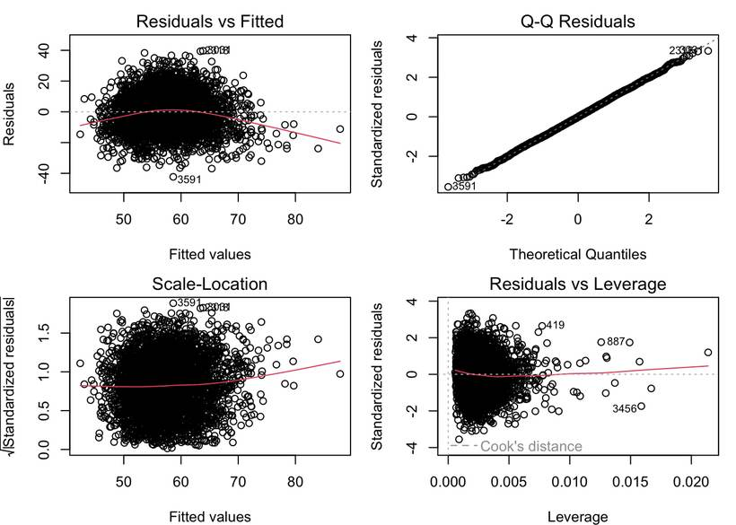

```r
par(mfrow=c(2,2), mar=c(4,4,2,1))
plot(Food_Lm)
```

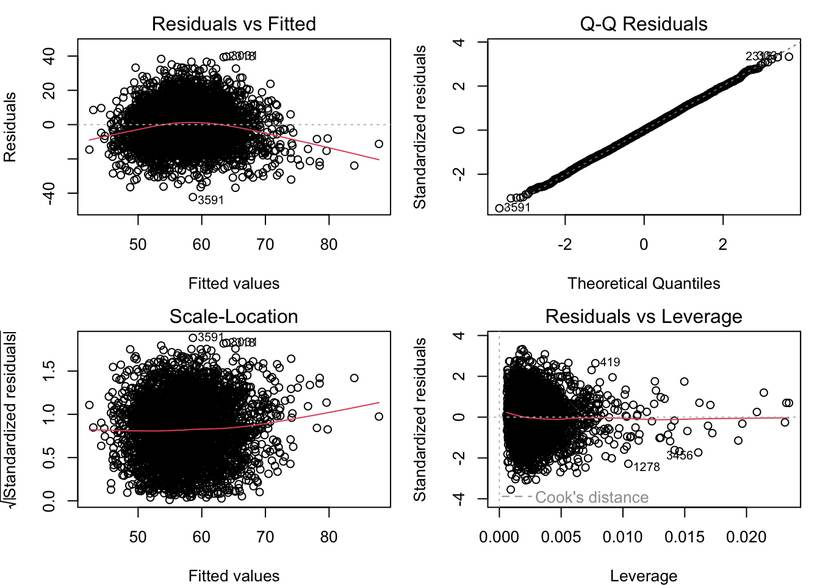

```r
par(mfrow=c(2,2), mar=c(4,4,2,1))
plot(Food_Lm_Int)
```

```r
par(mfrow=c(1,1))
```

**Interpretation**

**Diagnostics: Food_Lm (Main-effects model)**

Diagnostic plots indicated no major violations of linear regression assumptions. Residuals were approximately normally distributed, with no strong evidence of heteroscedasticity or influential observations, supporting the validity of model inference

**Diagnostics: Food_Lm_Int (Alcohol × Debt interaction)**

Diagnostic plots for the interaction model were similar to those of the main-effects model. Assumptions of linearity, normality, and constant variance appeared reasonable, indicating that the interaction results can be interpreted reliably

**Final Conclusion**

Household food expenditure is only partially explained by the variables available in this dataset (R² ≈ 0.15). Housing expenditure and alcohol spending were positively associated with food expenditure, while higher debt repayments were associated with slightly lower food spending. Household demographic characteristics such as household size, number of children, income category, and respondent sex did not show strong independent associations once expenditure variables were included. There was no evidence that household debt modifies the relationship between alcohol and food expenditure, as the Alcohol × Debt interaction was not statistically significant. Overall, food expenditure appears more strongly related to other financial commitments than to household demographics

# Part 2: Podcast Streaming Performance

This dataset contains aggregated averages for individual podcasts collected over an extended period, with each row representing a single podcast. The main outcome of interest is average daily listens. Alongside listens, the data record average review score, total number of reviews, subscriber count, and podcast genre.

The analysis explores the relationships between podcast characteristics and listening patterns, with particular focus on review metrics and how their association with daily listens varies across different podcast genres and subscriber levels.

The table below provides a brief description of each variable in the data set

# Data Dictionary

[output not shown]

# Data overview

```r
# Read podcast data

podcasts <- read_csv("podcast_listens.csv", col_names = c( "platform","genre","review.score", "daily.listens", "total.reviews", "subscribers"), skip = 1)

# Quick structure and summary
glimpse(podcasts)
```

```
Rows: 5,400
Columns: 6
$ platform      <chr> "Apple Podcasts", "Spotify", "Apple Podcasts", "YouTube", "Apple Podcasts", …
$ genre         <chr> "Comedy", "News & Culture", "Documentary", "Comedy", "News & Culture", "News…
$ review.score  <dbl> 3.78, 4.70, 3.98, 4.71, 4.70, 4.55, 4.40, 4.84, 3.66, 4.34, 4.45, 3.93, 4.25…
$ daily.listens <dbl> 4683.26, 4336.52, 4277.50, 4717.49, 4267.62, 4623.31, 4228.83, 4667.00, 4335…
$ total.reviews <dbl> 984, 1005, 968, 1132, 690, 991, 970, 956, 1072, 1202, 1175, 886, 778, 842, 1…
$ subscribers   <dbl> 549.94, 340.07, 693.57, 622.02, 311.37, 301.99, 849.31, 495.58, 833.02, 869.…
```

```r
summary(podcasts)
```

```
   platform            genre            review.score     daily.listens  total.reviews
 Length:5400        Length:5400        Min.   :  0.000   Min.   :3951   Min.   :   0.0
 Class :character   Class :character   1st Qu.:  4.140   1st Qu.:4372   1st Qu.: 849.0
 Mode  :character   Mode  :character   Median :  4.440   Median :4507   Median : 958.0
                                       Mean   :  4.747   Mean   :4520   Mean   : 951.5
                                       3rd Qu.:  4.660   3rd Qu.:4663   3rd Qu.:1064.0
                                       Max.   :100.000   Max.   :5188   Max.   :1506.0
  subscribers
 Min.   :  -2.0
 1st Qu.: 492.5
 Median : 614.2
 Mean   : 627.8
 3rd Qu.: 760.9
 Max.   :1191.9
```

```r
colSums(is.na(podcasts))
```

```
     platform         genre  review.score daily.listens total.reviews   subscribers
            0             0             0             0             0             0
```

Overall, the data is suitable for modelling and the only clear inconsistency is the number of invalid negative value and outliers in some variable, which are handled in the cleaning step below

# Handling inconsistency

The dataset contains 5,400 podcasts and six variables. Inspection revealed a small number of invalid values, including negative subscriber counts (i.e −2) and review scores outside the plausible 1–5 rating scale. Negative subscriber counts are not meaningful in practice, and review scores outside this range are inconsistent with standard podcast rating systems and were rare in the data. These values were therefore treated as data errors and set to missing. A complete-case dataset was then created for the variables used in modelling, resulting in a final analysis sample of n = 5,353 podcasts.

```r
podcasts_filtered <- podcasts %>%
  mutate(
    subscribers   = ifelse(subscribers < 0, NA, subscribers),
    daily.listens = ifelse(daily.listens < 0, NA, daily.listens),
    total.reviews = ifelse(total.reviews < 0, NA, total.reviews),
    review.score  = ifelse(review.score < 0, NA, review.score)
  ) %>%
  mutate(
    review.score = ifelse(review.score < 1 | review.score > 5, NA, review.score),
    platform = factor(platform),
    genre    = factor(genre)
  ) %>%
  filter(
    !is.na(daily.listens),
    !is.na(review.score),
    !is.na(total.reviews),
    !is.na(subscribers),
    !is.na(genre))

glimpse(podcasts_filtered)
```

```
Rows: 5,353
Columns: 6
$ platform      <fct> Apple Podcasts, Spotify, Apple Podcasts, YouTube, Apple Podcasts, Apple Podc…
$ genre         <fct> Comedy, News & Culture, Documentary, Comedy, News & Culture, News & Culture,…
$ review.score  <dbl> 3.78, 4.70, 3.98, 4.71, 4.70, 4.55, 4.40, 4.84, 3.66, 4.34, 4.45, 3.93, 4.25…
$ daily.listens <dbl> 4683.26, 4336.52, 4277.50, 4717.49, 4267.62, 4623.31, 4228.83, 4667.00, 4335…
$ total.reviews <dbl> 984, 1005, 968, 1132, 690, 991, 970, 956, 1072, 1202, 1175, 886, 778, 842, 1…
$ subscribers   <dbl> 549.94, 340.07, 693.57, 622.02, 311.37, 301.99, 849.31, 495.58, 833.02, 869.…
```

```r
summary(podcasts_filtered)
```

```
           platform               genre       review.score   daily.listens  total.reviews
 Apple Podcasts:3863   Comedy        :1786   Min.   :1.000   Min.   :3951   Min.   : 408.0
 BBC Sounds    : 160   Documentary   :1781   1st Qu.:4.140   1st Qu.:4372   1st Qu.: 852.0
 Spotify       : 827   News & Culture:1786   Median :4.440   Median :4508   Median : 960.0
 YouTube       : 503                         Mean   :4.359   Mean   :4520   Mean   : 959.6
                                             3rd Qu.:4.660   3rd Qu.:4663   3rd Qu.:1066.0
                                             Max.   :5.000   Max.   :5188   Max.   :1506.0
  subscribers
 Min.   :  19.05
 1st Qu.: 492.52
 Median : 614.21
 Mean   : 627.91
 3rd Qu.: 760.54
 Max.   :1191.92
```

# Visualizing distributions of Variables of interest

## Daily listens

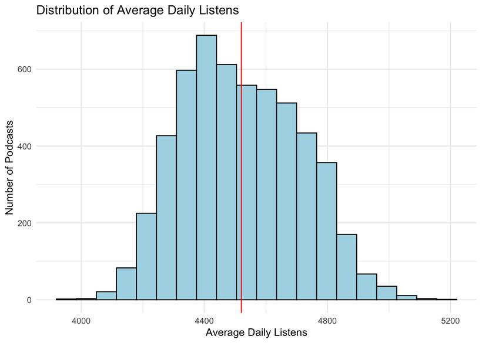

```r
ggplot(podcasts_filtered, aes(x = daily.listens)) +
  geom_histogram(bins = 20, fill = "lightblue", colour = "black") +
  geom_vline(
    xintercept = mean(podcasts_filtered$daily.listens, na.rm = TRUE),
    colour = "red") + theme_minimal() + labs( title = "Distribution of Average Daily Listens", x = "Average Daily Listens",y = "Number of Podcasts")
```

**Interpretation**

Daily listens are unimodal with a moderate right tail, indicating that while most podcasts receive similar average listening levels, a smaller number attract substantially larger audiences. Values appear plausible for aggregated listening data and suitable for linear modelling

## Review score

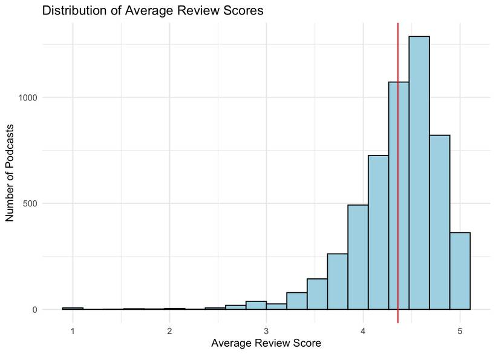

```r
ggplot(podcasts_filtered, aes(review.score)) +
  geom_histogram(bins = 20, fill = "lightblue", colour = "black") +
  geom_vline(aes(xintercept = mean(review.score)), colour = "red") +
  theme_minimal() + labs(title = "Distribution of Average Review Scores", x = "Average Review Score", y = "Number of Podcasts")
```

**Interpretation**

After removing invalid values, review scores are tightly concentrated between 4 and 5, with limited dispersion. This restricted range suggests that while review score may be statistically detectable, it is unlikely to explain large differences in daily listens

## Total Number of reviews

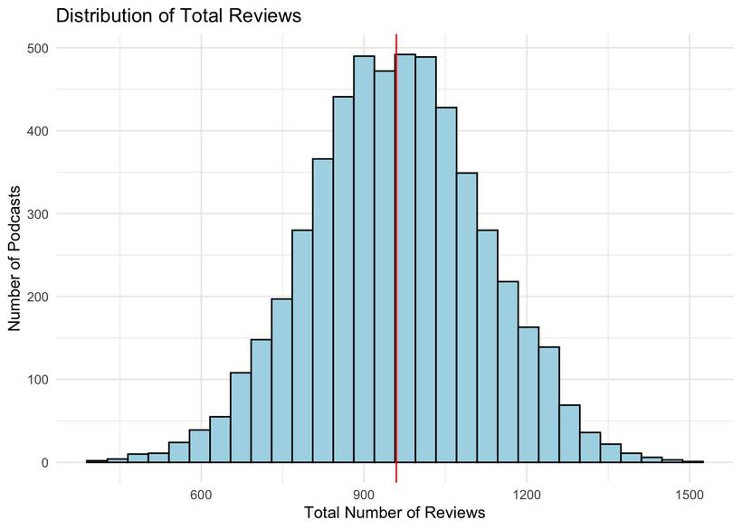

```r
ggplot(podcasts_filtered, aes(total.reviews)) +
  geom_histogram(bins = 30, fill = "lightblue", colour = "black") +
  geom_vline(aes(xintercept = mean(total.reviews)), colour = "red") +
  theme_minimal() +
  labs(
    title = "Distribution of Total Reviews",
    x = "Total Number of Reviews",
    y = "Number of Podcasts")
```

## Subscribers

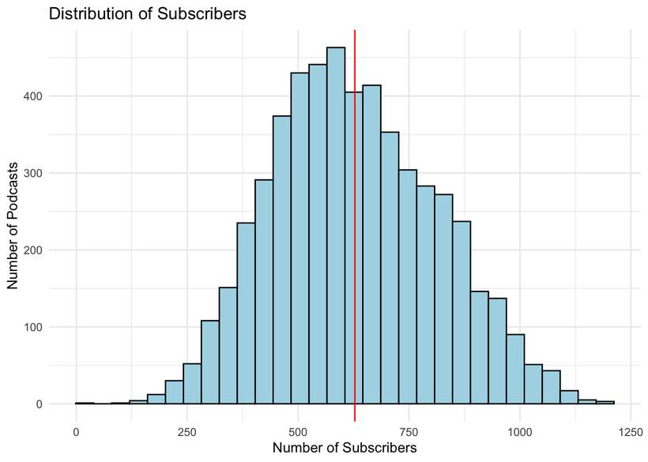

```r
ggplot(podcasts_filtered, aes(subscribers)) +
  geom_histogram(bins = 30, fill = "lightblue", colour = "black") +
  geom_vline(aes(xintercept = mean(subscribers)), colour = "red") +
  theme_minimal() +
  labs(
    title = "Distribution of Subscribers",
    x = "Number of Subscribers",
    y = "Number of Podcasts")
```

**Interpretation**

# Visualising relationships of Variables of interest

## Daily listens vs review score (by genre)

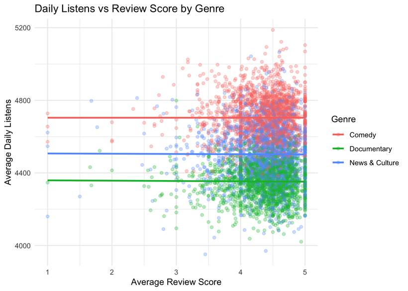

```r
ggplot(podcasts_filtered, aes(x = review.score, y = daily.listens, colour = genre)) +
  geom_point(alpha = 0.3) +
  geom_smooth(method = "lm", se = FALSE) +
  theme_minimal() +
  labs(
    title = "Daily Listens vs Review Score by Genre",
    x = "Average Review Score",
    y = "Average Daily Listens",
    colour = "Genre")
```

## Daily listens vs total reviews

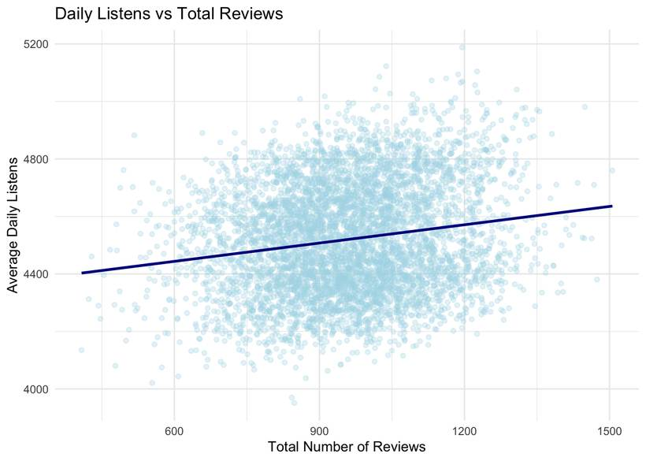

```r
ggplot(podcasts_filtered, aes(x = total.reviews, y = daily.listens)) +
  geom_point(alpha = 0.3, colour = "lightblue") +
  geom_smooth(method = "lm", se = FALSE, colour = "darkblue") +
  theme_minimal() +
  labs(
    title = "Daily Listens vs Total Reviews",
    x = "Total Number of Reviews",
    y = "Average Daily Listens")
```

**Interpretation**

A positive association is visible between total reviews and daily listens. however, the wide scatter indicates that review volume alone explains only a small proportion of variation in listening levels

## Daily listens vs subscribers (by genre)

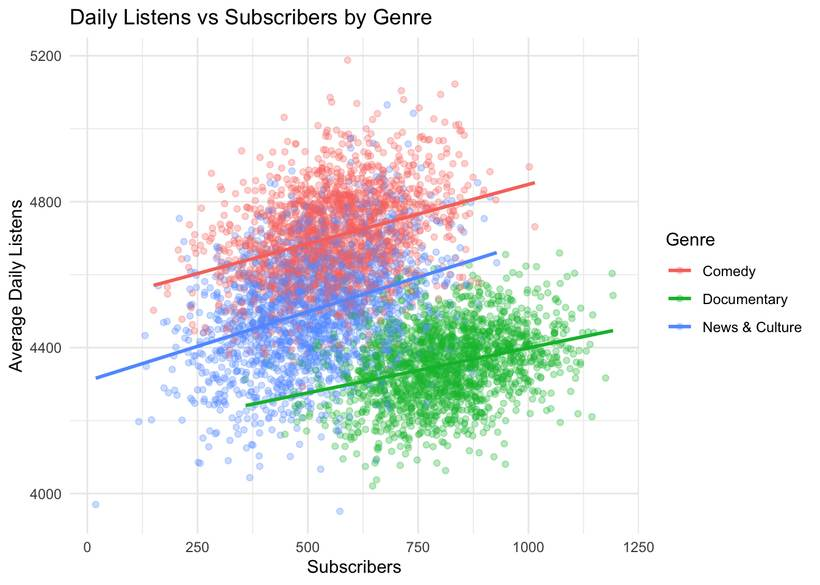

```r
ggplot(podcasts_filtered, aes(x = subscribers, y = daily.listens, colour = genre)) +
  geom_point(alpha = 0.3) +
  geom_smooth(method = "lm", se = FALSE) +
  theme_minimal() +
  labs(title = "Daily Listens vs Subscribers by Genre",
    x = "Subscribers",
    y = "Average Daily Listens",
    colour = "Genre")
```

**Interpretation**

A clear positive association is observed between subscribers and daily listens. Differences in both baseline levels and fitted slopes across genres motivate a subscribers × genre interaction model

**Together, all these distributions appear realistic and appropriate for linear modelling**

# Model 1: Daily.listens ~ Review.score + Total.reviews

A multiple linear regression model was fitted to test whether review score and total reviews explain variation in average daily listens

```r
Listen_reviews_main <- lm(
  daily.listens ~ review.score + total.reviews,
  data = podcasts_filtered)

summary(Listen_reviews_main)
```

```
Call:
lm(formula = daily.listens ~ review.score + total.reviews, data = podcasts_filtered)

Residuals:
    Min      1Q  Median      3Q     Max
-547.18 -149.98   -9.27  146.83  618.03

Coefficients:
                Estimate Std. Error t value Pr(>|t|)
(Intercept)   4327.04014   29.47180 146.820   <2e-16 ***
review.score    -2.45362    5.72994  -0.428    0.669
total.reviews    0.21223    0.01612  13.166   <2e-16 ***
---
Signif. codes:  0 '***' 0.001 '**' 0.01 '*' 0.05 '.' 0.1 ' ' 1

Residual standard error: 188.4 on 5350 degrees of freedom
Multiple R-squared:  0.03141,   Adjusted R-squared:  0.03105
F-statistic: 86.75 on 2 and 5350 DF,  p-value: < 2.2e-16
```

```r
confint(Listen_reviews_main)
```

```
                     2.5 %       97.5 %
(Intercept)   4269.2633968 4384.8168870
review.score   -13.6866354    8.7794051
total.reviews    0.1806281    0.2438324
```

**Interpretation**

**NHST: Overall model test**

H₀: Review score and total reviews do not explain variation in daily listens

H₁: At least one predictor is associated with daily listens

The model was statistically significant, F(2, 5350) = 86.75, p < .001, providing evidence against H₀.

**Model fit**

The model explained a small proportion of variation in daily listens (R² = 0.03141, adjusted R² = 0.03105), indicating limited explanatory power using review metrics alone.

**Key estimates (estimation approach)**

Review score was not associated with daily listens (β = −2.454, 95% CI [−13.687, 8.779], p = .669). Total reviews showed a clear positive association: each additional review was associated with 0.212 more daily listens (β = 0.212, 95% CI [0.181, 0.244], p < .001).

**Conclusion**

In this dataset, total review volume is associated with higher listens, but review score itself is not, and review metrics explain very little overall variation in daily listening levels

# Model 2: Daily.listens ~ Review.score + Total.reviews + Genre

Genre was added to test whether listening levels differ across genres after controlling for review score and total reviews

```r
Listen_reviews_genre <- lm(
  daily.listens ~ review.score + total.reviews + genre,
  data = podcasts_filtered)

summary(Listen_reviews_genre)
```

```
Call:
lm(formula = daily.listens ~ review.score + total.reviews + genre,
    data = podcasts_filtered)

Residuals:
    Min      1Q  Median      3Q     Max
-527.77  -74.45    0.29   76.32  508.24

Coefficients:
                     Estimate Std. Error t value Pr(>|t|)
(Intercept)         4392.4374    18.2685 240.438   <2e-16 ***
review.score          -1.0062     3.5069  -0.287    0.774
total.reviews          0.3314     0.0101  32.816   <2e-16 ***
genreDocumentary    -367.8628     3.8955 -94.433   <2e-16 ***
genreNews & Culture -190.8713     3.8718 -49.298   <2e-16 ***
---
Signif. codes:  0 '***' 0.001 '**' 0.01 '*' 0.05 '.' 0.1 ' ' 1

Residual standard error: 115.3 on 5348 degrees of freedom
Multiple R-squared:  0.6373,    Adjusted R-squared:  0.6371
F-statistic:  2350 on 4 and 5348 DF,  p-value: < 2.2e-16
```

```r
confint(Listen_reviews_genre)
```

```
                           2.5 %       97.5 %
(Intercept)         4356.6236506 4428.2511001
review.score          -7.8810826    5.8686335
total.reviews          0.3116175    0.3512148
genreDocumentary    -375.4995046 -360.2260086
genreNews & Culture -198.4615283 -183.2810936
```

**Interpretation**

**NHST: Overall model test**

H₀: None of the predictors are associated with daily listens

H₁: At least one predictor is associated with daily listens

The model was statistically significant, F(4, 5348) = 2350, p < .001

**Model fit**

Including genre substantially increased explained variance (R² = 0.6373; adjusted R² = 0.6371), indicating that genre accounts for a large share of variation in daily listens beyond review metrics

**Key estimates (estimation approach)**

After controlling for review score and total reviews, Documentary podcasts received substantially fewer daily listens than Comedy (β = −367.863, 95% CI [−375.500, −360.226], p < .001), and News & Culture podcasts also received fewer daily listens than Comedy (β = −190.871, 95% CI [−198.462, −183.281], p < .001). Total reviews remained positively associated with listens (β = 0.331, 95% CI [0.312, 0.351], p < .001), while review score was not associated (β = −1.006, 95% CI [−7.882, 5.868], p = .774)

**Conclusion**

Genre is the dominant determinant of daily listens, while total reviews adds a smaller but statistically clear association; review score adds no evidence of additional explanatory value once the other variables are included

# Emmeans For Genre

Estimated marginal means were computed to compare expected daily listens across podcast genres after controlling for review score and total reviews

```r
emmeans(Listen_reviews_genre, ~ genre)
```

```
 genre          emmean   SE   df lower.CL upper.CL
 Comedy           4706 2.73 5348     4701     4711
 Documentary      4338 2.77 5348     4333     4344
 News & Culture   4515 2.76 5348     4510     4521

Confidence level used: 0.95
```

**Interpretation**

Estimated marginal means from the adjusted model show expected daily listens after controlling for review score and total reviews. Comedy had the highest adjusted daily listens (4706, 95% CI [4701, 4711]), followed by News & Culture (4515, 95% CI [4510, 4521]), with Documentary lowest (4338, 95% CI [4333, 4344]). These adjusted means provide a clear summary of genre differences holding review metrics constant

# Model 3: Daily.listens ~ Subscribers + Genre

A regression model was fitted to examine whether subscribers predict daily listens and whether baseline listening levels differ by genre

```r
Listen_subs_main <- lm(
  daily.listens ~ subscribers + genre,
  data = podcasts_filtered)

summary(Listen_subs_main)
```

```
Call:
lm(formula = daily.listens ~ subscribers + genre, data = podcasts_filtered)

Residuals:
    Min      1Q  Median      3Q     Max
-570.70  -76.02   -0.66   76.37  508.84

Coefficients:
                      Estimate Std. Error t value Pr(>|t|)
(Intercept)         4525.01624    7.54515  599.73   <2e-16 ***
subscribers            0.31951    0.01249   25.57   <2e-16 ***
genreDocumentary    -431.67631    5.09188  -84.78   <2e-16 ***
genreNews & Culture -185.88050    4.03766  -46.04   <2e-16 ***
---
Signif. codes:  0 '***' 0.001 '**' 0.01 '*' 0.05 '.' 0.1 ' ' 1

Residual standard error: 119.3 on 5349 degrees of freedom
Multiple R-squared:  0.6118,    Adjusted R-squared:  0.6116
F-statistic:  2810 on 3 and 5349 DF,  p-value: < 2.2e-16
```

```r
confint(Listen_subs_main)
```

```
                           2.5 %      97.5 %
(Intercept)         4510.2246649 4539.807813
subscribers            0.2950176    0.344005
genreDocumentary    -441.6584679 -421.694144
genreNews & Culture -193.7959610 -177.965036
```

**Interpretation**

**NHST: Overall model test**

H₀: Subscribers and genre are not associated with daily listens

H₁: At least one predictor is associated with daily listens

The model was statistically significant, F(3, 5349) = 2810, p < .001

**Model fit**

The model explained a substantial proportion of variation in daily listens (R² = 0.6118,; adjusted R² = 0.6116,)

**Key estimates (estimation approach)**

Subscriber count was a strong positive predictor: each additional subscriber was associated with 0.320 more daily listens (β = 0.3195, 95% CI [0.2950, 0.3440], p < .001). After controlling for subscribers, Documentary podcasts received fewer daily listens than Comedy (β = −431.676, 95% CI [−441.658, −421.694], p < .001), and News & Culture also received fewer listens than Comedy (β = −185.881, 95% CI [−193.796, −177.965], p < .001)

**Conclusion**

Subscribers and genre together explain a large share of variation in daily listens, with subscriber count showing a strong positive association and substantial baseline differences remaining between genres

# Model 4: Daily.Listens ~ Subscribers * Genre & Anova Test

An interaction model was fitted to test whether the association between subscribers and daily listens differs by genre. Moreover, an ANOVA was used to test whether including a Subscribers × Genre interaction significantly improves model fit over the additive model

```r
Listen_subs_interact <- lm(
  daily.listens ~ subscribers * genre,
  data = podcasts_filtered)

summary(Listen_subs_interact)
```

```
Call:
lm(formula = daily.listens ~ subscribers * genre, data = podcasts_filtered)

Residuals:
    Min      1Q  Median      3Q     Max
-574.32  -76.12    0.70   76.28  498.85

Coefficients:
                                  Estimate Std. Error t value Pr(>|t|)
(Intercept)                     4521.50636   12.78340 353.701   <2e-16 ***
subscribers                        0.32578    0.02226  14.632   <2e-16 ***
genreDocumentary                -369.09082   22.12266 -16.684   <2e-16 ***
genreNews & Culture             -212.70719   16.83776 -12.633   <2e-16 ***
subscribers:genreDocumentary      -0.07895    0.03126  -2.526   0.0116 *
subscribers:genreNews & Culture    0.05305    0.03041   1.745   0.0811 .
---
Signif. codes:  0 '***' 0.001 '**' 0.01 '*' 0.05 '.' 0.1 ' ' 1

Residual standard error: 119.1 on 5347 degrees of freedom
Multiple R-squared:  0.6132,    Adjusted R-squared:  0.6128
F-statistic:  1695 on 5 and 5347 DF,  p-value: < 2.2e-16
```

```r
confint(Listen_subs_interact)
```

```
                                        2.5 %        97.5 %
(Intercept)                      4.496446e+03 4546.56703172
subscribers                      2.821317e-01    0.36942510
genreDocumentary                -4.124602e+02 -325.72138621
genreNews & Culture             -2.457161e+02 -179.69831434
subscribers:genreDocumentary    -1.402300e-01   -0.01767034
subscribers:genreNews & Culture -6.555771e-03    0.11265881
```

```r
anova(Listen_subs_main, Listen_subs_interact)
```

```
Analysis of Variance Table

Model 1: daily.listens ~ subscribers + genre
Model 2: daily.listens ~ subscribers * genre
  Res.Df      RSS Df Sum of Sq      F    Pr(>F)
1   5349 76109111
2   5347 75835971  2    273141 9.6292 6.693e-05 ***
---
Signif. codes:  0 '***' 0.001 '**' 0.01 '*' 0.05 '.' 0.1 ' ' 1
```

**Interpretation**

**NHST: Interaction test**

H₀: The association between subscribers and daily listens does not differ by genre H₁: The association differs by genre

The ANOVA comparison showed the interaction model improved fit relative to the additive model, F(2, 5347) = 9.63, p = 6.69×10⁻⁵

**Model fit**

The interaction model explained slightly more variance (R² = 0.6132; adjusted R² = 0.6128) than the additive model, indicating a small but statistically reliable improvement.

**Key estimates (estimation approach)**

For the reference genre (Comedy), each additional subscriber was associated with 0.326 more daily listens (β = 0.3258, 95% CI [0.282, 0.369], p < .001). The Subscribers × Documentary interaction was negative and statistically significant (β = −0.0790, 95% CI [−0.140, −0.018], p = .0116), indicating that subscriber gains translate into smaller listening increases for Documentary podcasts than for Comedy. The Subscribers × News & Culture interaction was positive but not statistically significant at the 5% level (β = 0.0531, 95% CI [−0.0066, 0.1127], p = .081)

**Conclusion**

Because the interaction improves fit and directly answers whether subscriber effects differ by genre, Model 4 is preferred for inference about genre-specific subscriber effects. However, the improvement in explained variance over Model 3 is small, so Model 3 remains a reasonable simpler summary model if the goal is parsimony rather than interaction interpretation.

# Estimated Subscriber Effects by Genre (emtrends)

Estimated marginal trends were computed to examine whether the association between subscribers and daily listens differs across podcast genres

```r
emtrends(Listen_subs_interact, ~ genre, var = "subscribers")
```

```
 genre          subscribers.trend     SE   df lower.CL upper.CL
 Comedy                     0.326 0.0223 5347    0.282    0.369
 Documentary                0.247 0.0219 5347    0.204    0.290
 News & Culture             0.379 0.0207 5347    0.338    0.419

Confidence level used: 0.95
```

**Interpretation**

Estimated trends quantify the expected change in daily listens per additional subscriber for each genre. The expected increase is 0.326 for Comedy (95% CI [0.282, 0.369]), 0.247 for Documentary (95% CI [0.204, 0.290]), and 0.379 for News & Culture (95% CI [0.338, 0.419]). This directly supports the interaction result that subscriber growth translates into smaller listening gains for Documentary podcasts than for Comedy.

# Diagnostics

Model diagnostics were examined to assess whether the assumptions of linear regression were reasonably satisfied

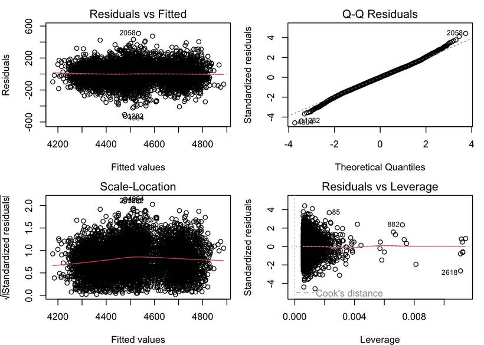

```r
par(mfrow=c(2,2), mar=c(4,4,2,1))
plot(Listen_reviews_genre)
```

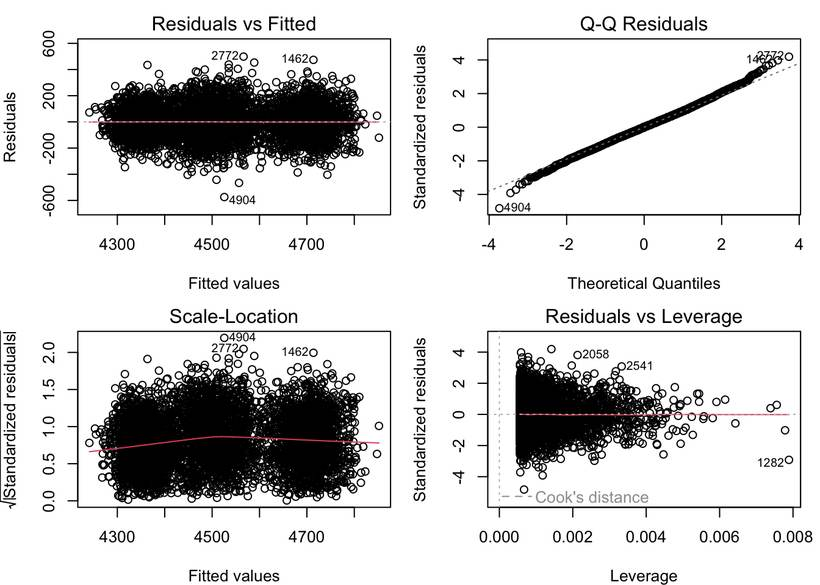

```r
par(mfrow=c(1,1))

par(mfrow=c(2,2), mar=c(4,4,2,1))
plot(Listen_subs_interact)
```

```r
par(mfrow=c(1,1))
```

**Interpretation**

**Diagnostics: Listen_reviews_genre**

Diagnostic plots showed no major violations of linear regression assumptions. Residuals were approximately normally distributed, with no strong evidence of heteroscedasticity or influential observations, supporting the validity of model inference.

**Diagnostics: Listen_subs_interact**

Diagnostic plots indicated that linearity and normality assumptions were reasonably satisfied. Residual variance was broadly constant across fitted values, and no influential observations were detected, supporting reliable interpretation of the interaction effects.

**Therefore, There was also no indication of problematic multicollinearity, as coefficient estimates were stable and standard errors were reasonable across models**

**Final Conclusion**

Review score and total reviews explain only a small proportion of variation in daily listens (R² ≈ 0.03). In contrast, subscriber count and genre explain a substantial share of listening differences across podcasts (R² ≈ 0.61–0.63). Subscriber growth is positively associated with daily listens across all genres, but this association is significantly weaker for Documentary podcasts than for Comedy. Overall, podcast popularity is driven primarily by audience size and genre rather than review-based metrics.